# Day5_seaborn

## DAY5: Visualization:Seaborn

### Distribution plots

- distplot
- joinplt
- pairplt

```python
# Analysing the dataset
# it could be classification or regression based on supervised learning.
# there dataset will have features like f1 f2 f3 f4 .
# step1 is to identify the independent and dependent features,
```

```python
# whenever comparing 2 features -> bivariate analyse -> create 2d graph and analysis-> done with seaborn.
# generally whenever to analyse 2 features then we use  joinplt visualization
# if we have number of feature(more then 2) then we use distplt,pairplt like thing.
```

```python
import seaborn as sns
```

```python
# inbuilt function  -> load_dataset
# And inseide seaborn here we have a dataset which is tips
```

```python
df=sns.load_dataset("tips")
```

```python
df.head()
```

|  | total_bill | tip | sex | smoker | day | time | size |
| --- | --- | --- | --- | --- | --- | --- | --- |
| 0 | 16.99 | 1.01 | Female | No | Sun | Dinner | 2 |
| 1 | 10.34 | 1.66 | Male | No | Sun | Dinner | 3 |
| 2 | 21.01 | 3.50 | Male | No | Sun | Dinner | 3 |
| 3 | 23.68 | 3.31 | Male | No | Sun | Dinner | 2 |
| 4 | 24.59 | 3.61 | Female | No | Sun | Dinner | 4 |

### Correlation with Heatmap

A correlation heatmap uses colored cells, typically in a monochromatic scale, to show a 2D correlation matrix (table) between two discrete dimensions or event types. It is very important in Feature Selection

```python
# we have to create a model such that we are able to predict the tip based on other parameters.
# tip is dependent feature.
# total bill, sex, smoker,day,time,size all this is independent feature.

# heatmap help to analyse the colrelation between all the features -> can be found out only if they are int or float.
# if values are categarial feature it is not possible as it is categaru type.
# value range byw -1 to 1 . coeff corealation.
```

```python
## It is very important in process of feature selection.
```

```python
numeric_df = df.select_dtypes(include=['float64', 'int64'])
correlation_matrix = numeric_df.corr()
print(correlation_matrix)
```

```
            total_bill       tip      size
total_bill    1.000000  0.675734  0.598315
tip           0.675734  1.000000  0.489299
size          0.598315  0.489299  1.000000
```

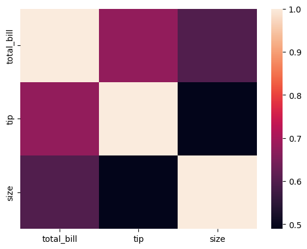

```python
sns.heatmap(correlation_matrix)
```

## 1 JoinPlot

- A join plot allows to study the relationship between 2 numeric variables.
- The central chart display their correlation.
- It is usually a scatterplot, a hexbin plot, a 2D histogram or a 2D density plot

#### Bivariate Analysis:

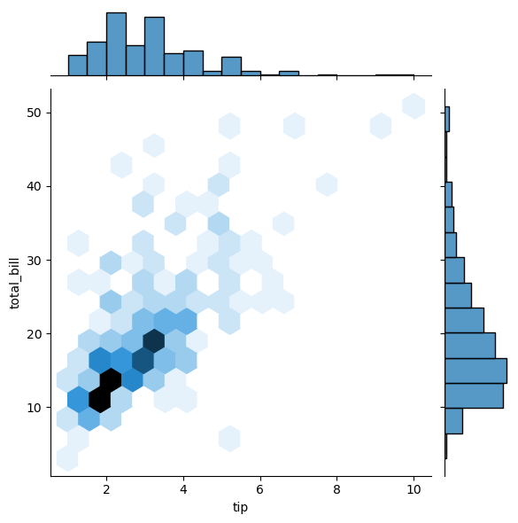

```python
sns.jointplot(x='tip',y='total_bill',data=df,kind='hex')
```

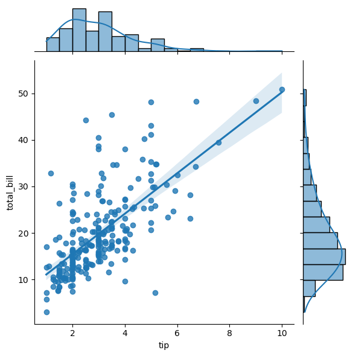

```python
sns.jointplot(x='tip',y='total_bill',data=df,kind='reg')
```

## 2: Pair plot

```python
# more then 2 efatures -> permutation and comb of all features.
```

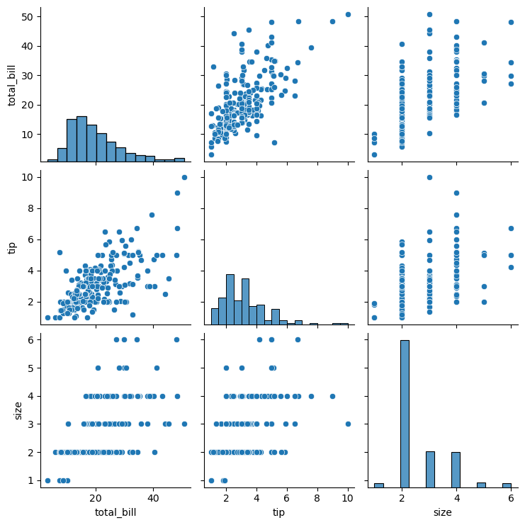

```python
sns.pairplot(df)
```

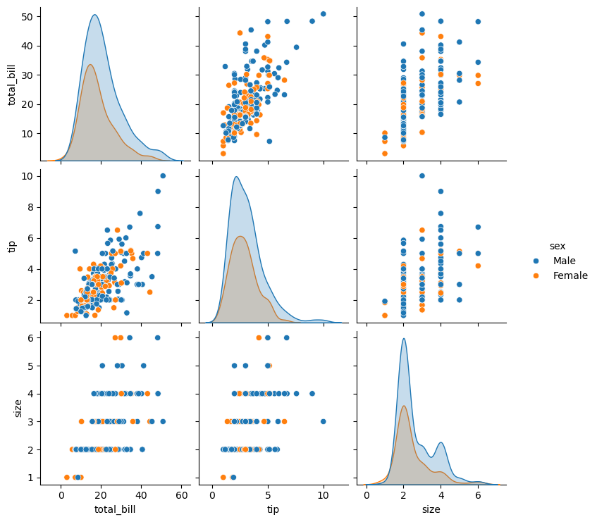

```python
sns.pairplot(df,hue='sex') # hue parameter is used
```

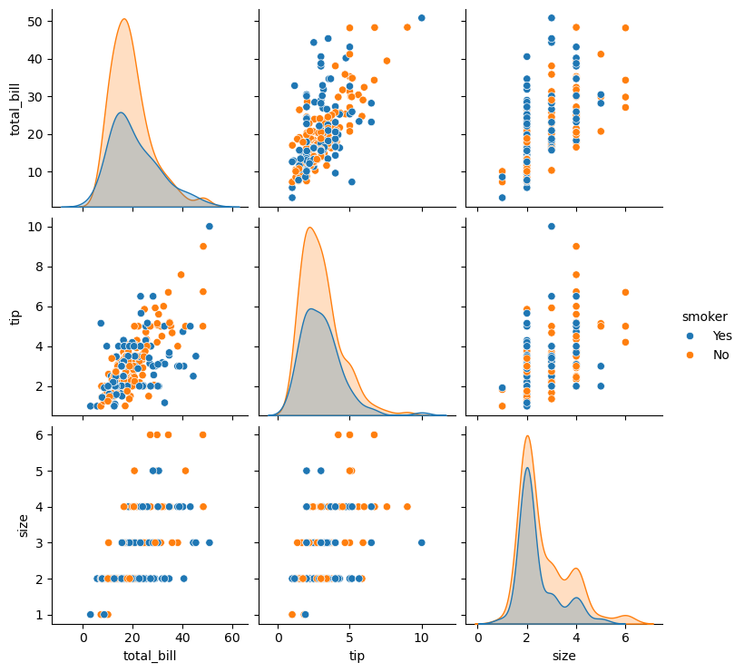

```python
sns.pairplot(df,hue='smoker')
```

```python
df['smoker'].value_counts()
```

```
smoker
No     151
Yes     93
Name: count, dtype: int64
```

## 3.Dist plot

- Dist plot helps us to check the distribution of the columns feature

[output not shown]

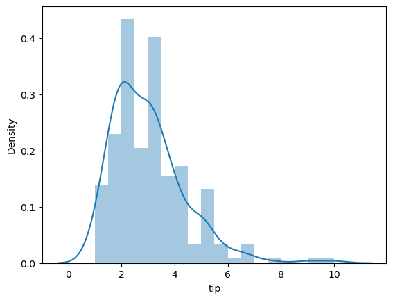

```python
sns.distplot(df['tip'])
```

[output not shown]

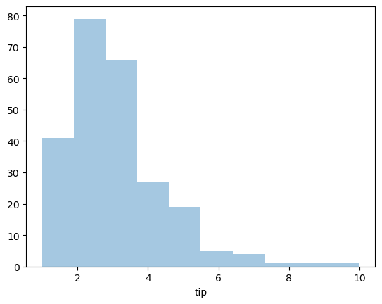

```python
sns.distplot(df['tip'],kde=False,bins=10)
```

## Categorical plot

Seaborn also helps us in doing the analysis on Categorical Data points. In this section we will discuss about

- box plot
- violinplot
- countplot
- bar plot

## 1 Count plot

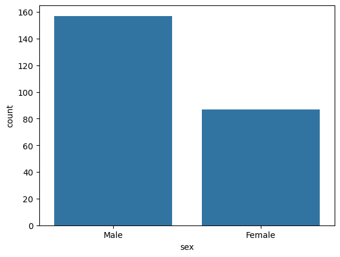

```python
sns.countplot(x='sex',data=df)
```

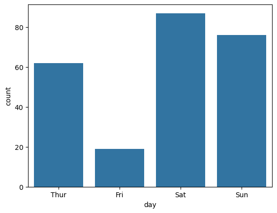

```python
sns.countplot(x='day',data=df)
```

## 2. Bar plot : here both x axis and y axis

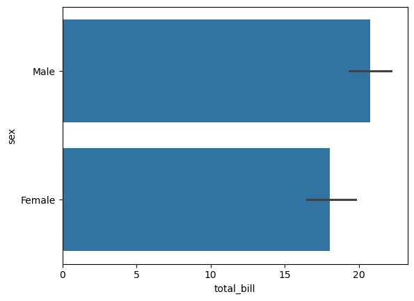

```python
sns.barplot(x='total_bill',y='sex',data=df)
```

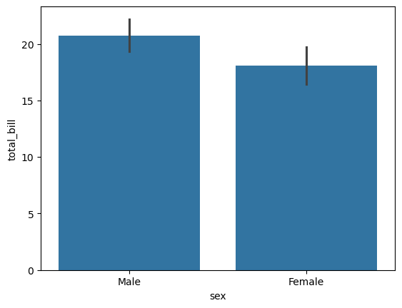

```python
sns.barplot(x='sex',y='total_bill',data=df)
```

## 3.Box plot

- A box and whisker plot (sometimes called a boxplot) is a graph that presents information from a five-number summary.

[output not shown]

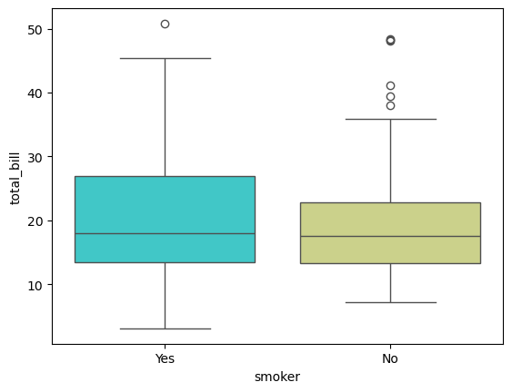

```python
sns.boxplot(x='smoker', y='total_bill', data=df,palette='rainbow')
```

[output not shown]

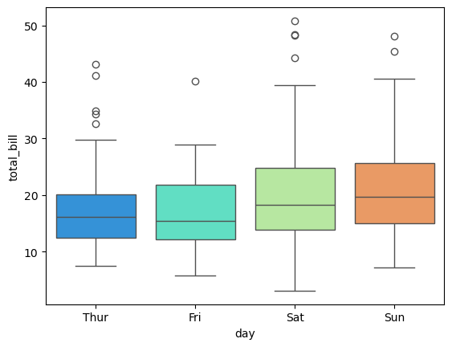

```python
sns.boxplot(x="day", y="total_bill", data=df,palette='rainbow')
```

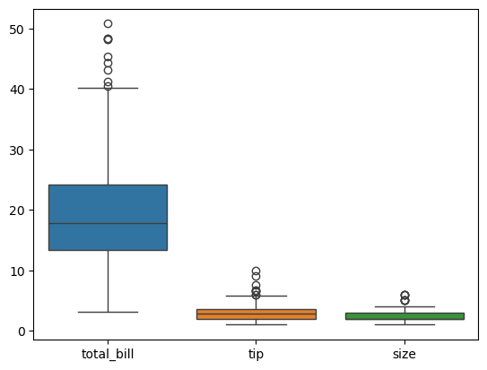

```python
sns.boxplot(data=df,orient='v')
```

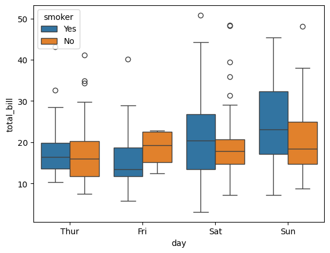

```python
sns.boxplot(y="total_bill", x="day",orient='v', hue="smoker",data=df)
```

## 4. Violin plot

- Violin plot helps us to see both the distribution of data in terms of Kernel density estimation and the box plot

[output not shown]

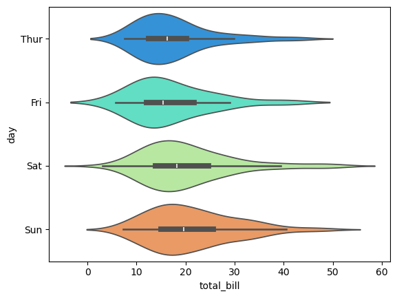

```python
sns.violinplot(x="total_bill", y="day", data=df,palette='rainbow')
```